# Laboratorio 1.2: Exploración y Visualización de Datos

Felipe Jara y Manuel Sepúlveda

Abril 2023

# Declaración de compromiso ético

Nosotros **Felipe Mauricio Jara Ribet y Manuel Alejandro Sepúlveda Cabeza sección 1 y 2**, declaramos que realizamos de manera grupal los pasos de la presente actividad. También declaramos no incurrir en copia, ni compartir nuestras respuestas con otras personas ni con otros grupos. Por lo que, ratificamos que las respuestas son de nuestra propia confección y reflejan nuestro propio conocimiento.

# Instrucciones

1. Trabajen en equipos de dos personas. Salvo excepciones, no se corregirá entregas con menos de dos integrantes.
2. Modifique este archivo `.Rmd` agregando sus respuestas donde corresponda.
3. Para cada pregunta, cuando corresponda, **incluya el código fuente que utilizó para llegar a su respuesta**.
4. El formato de entrega para esta actividad es un archivo html. **Genere un archivo HTML usando RStudio** y súbalo a U-Cursos.

Basta con que uno de los integrantes haga la entrega. Si ambos hacen una entrega en U-Cursos, se revisará cualquiera de éstas.

# Laboratorio

La primera parte de esta actividad son preguntas teóricas que avanzaron en las clases del curso de Minería de datos.

## Teoría

*1. ¿Cuál es la diferencia entre los atributos cualitativos y los cuantitativos? ¿Se puede transformar un atributo cuantitativo en cualitativo y viceversa? Ejemplifique.*

**Respuesta:**

*2. ¿Qué factores que ocasionan errores en el análisis de datos deben ser considerados para la limpieza de un set de datos? ¿Qué técnica estadística podría utilizar durante el proceso de limpieza? Ejemplifique con al menos una técnica.*

**Respuesta:** Los factores que deben ser considerados deben ser los outliers, datos faltantes, ruido, datos duplicados, sesgo, entre otros. Existen varias técnicas para lidiar con los distinos problemas, como la agregación, el muestreo, y PCA. El muestreo toma en cuenta sólo una fracción de los datos, normalmente elegidos aleatoriamente, esto ayuda a controlar el sesgo, pero se arriesga a que los outliers afecten mucho a los datos si la muestra no es lo suficientemente grande.

*3. Describa dos medidas de tendencia central y explique sus posibles utilidades para el análisis exploratorio de datos.*

**Respuesta:** La media es la mas conocida, esta se obtiene al dividir la suma de varios valores por la cantidad de estos valores, el gran problema de la media es que es muy sensible a outliers o valores atipicos, ya que afectan fuertemente en el resultado dando una ilusion sobre los datos errada.

La mediana representa la posicion central de la variable que separa la mitad inferior de la superior de los datos, es decir que la mitad de valores son menores o iguales a el y la otra mayores o iguales a el.

*4. ¿Qué es una matriz de correlación y para qué sirve?*

**Respuesta:**

*5. ¿Cuál es la utilidad de las visualizaciones en el análisis de datos? Ejemplifique.*

**Respuesta:**

## Práctica (Todas las preguntas deben agregar código que respalde su respuesta).

### Accidentes de tránsito

Para esta sección utilizaremos un dataset real de número de accidentes de tránsito por localidad, el cual puede ser encontrado en el siguiente link: http://datos.gob.cl/dataset/9348. Para cargar el dataset ejecute el siguiente código:

```r
tipos <- read.table("https://users.dcc.uchile.cl/~hsarmien/mineria/datasets/accidentes_2010_2011.txt")
head(tipos)
```

```
##    Muestra                  Descripcion Anio TipoAccidente Cantidad
## 1 Nacional                     Nacional 2010     Atropello     8247
## 2 Nacional                     Nacional 2011     Atropello     8339
## 3 Regional XV Región Arica y Parinacota 2010     Atropello      115
## 4 Regional XV Región Arica y Parinacota 2011     Atropello      159
## 5  Comunal                        ARICA 2010     Atropello      115
## 6  Comunal                        ARICA 2011     Atropello      158
```

Explore el set de datos para responder las siguientes preguntas:

1. ¿Cuáles son las dimensiones del dataset (filas, columnas)? (Recuerde adjuntar código).

```r
dim(tipos)
```

```
## [1] 4296    5
```

2. ¿Qué describe cada línea del dataset? (ejemplifique tomando el dato de la fila 235, extienda la descripción)

La linea describe la cantidad de accidentes de transito en un cierto año, si son de region/comuna y el nombre de esta, ademas el tipo de accidente al que pertenece esta cantidad. En la fila 235, hubieron 4 atropellos en la comuna de Palmilla, el año 2010.

```r
tipos[235, ]
```

```
##     Muestra Descripcion Anio TipoAccidente Cantidad
## 235 Comunal    PALMILLA 2010     Atropello        4
```

3. ¿Cuántos años diferentes abarca la información el dataset? Entregue una tabla que contenga los valores únicos que hay en la columna Anio.

```r
unique(tipos$Anio)
```

```
## [1] 2010 2011
```

4. Filtre los datos y genere un dataframe en el cual se indique la cantidad de accidentes tipo `Colision` que ocurrieron en el año `2011` y que no sean de la muestra `Nacional`.

```r
agregacion<-aggregate(Cantidad ~ TipoAccidente + Anio + Muestra, tipos, FUN=sum)

colisiones<-agregacion[agregacion$TipoAccidente == "Colision" & agregacion$Anio == 2011 & agregacion$Muestra != "Nacional",]
colisiones
```

```
##    TipoAccidente Anio  Muestra Cantidad
## 10      Colision 2011  Comunal    31487
## 34      Colision 2011 Regional    31487
```

La tabla nos muestra la cantidad de colisiones en las muestras regional y comunal, se nos pide sumar esas cantidades, pero notar que la suma no representa la cantidad de accidentes el año 2011, ya que al haber comunas dentro de las regiones, los datos se repiten. Ahora sumamos:

```r
sum(colisiones[, c("Cantidad")])
```

```
## [1] 62974
```

5. Filtre los datos para incluir sólo los accidentes ocurridos el año 2010 a nivel regional. Genere un boxplot donde se indique la cantidad de accidentes categorizado por tipo de accidente.

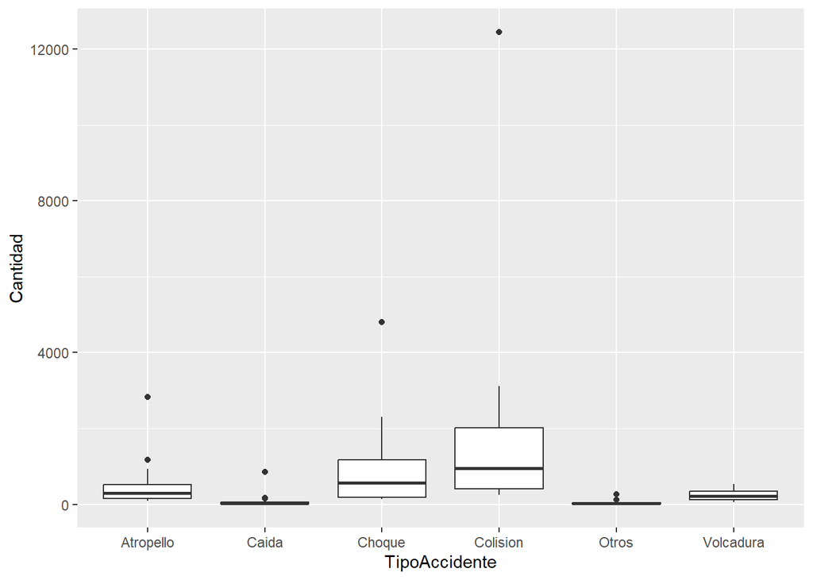

```r
library(ggplot2)
tipos2010 <- with(tipos,tipos[Muestra == "Regional" & Anio == 2010, ])
ggplot(tipos2010, aes(x = TipoAccidente, y = Cantidad)) +
  geom_boxplot()
```

6. ¿Qué otra forma de explorar los datos podría agregar para el dataset de Accidentes de tránsito y qué información adicional aporta? Adjunte el código necesario.

Se podría ver los tipos de accidente más comunes por región/comuna, también ver el cambio de la cantidad de accidentes de un año a otro. Si tuvieramos información sobre la población, podríamos ajustar los datos para saber en que parte del país es más o menos probable involucrarse en un accidente de tránsito.

### Tweets con hashtag #GPT4

A collection of tweets with the hashtag #GPT4

Considere el set de datos de tweets con el hashtag #GPT4 las siguientes columnas:

- date: fecha
- text: mensaje del tweet
- user_name: nombre de usuario
- user_location: lugar donde se emitio el tweet
- user_description: descripción del usuario
- user_created: fecha de creación del usuario
- user_followers: número de usuario que siguen al usuario de la observación
- user_friends: número de amigos de usuarios
- user_favourites: número de usuarios favoritos
- user_verified: si el usuario esta verificado o no
- hashtags: hashtags contenidos en el tweet.
- source: fuente del tweet.

```r
# Load Tweets dataset

tweets <- read.csv("https://raw.githubusercontent.com/giturra/lab1.2/main/tweets.csv")
head(tweets)
```

```
##                        date
## 1 2023-03-30 22:58:03+00:00
## 2 2023-03-30 22:57:34+00:00
## 3 2023-03-30 22:55:11+00:00
## 4 2023-03-30 22:53:55+00:00
## 5 2023-03-30 22:53:53+00:00
## 6 2023-03-30 22:53:38+00:00
##                                                                                                                                                                                                                                                                                        text
## 1                                                                                              Never give a poet access to the world's latest greatest language model, amirite, @Merzmensch! (Hope you are well, my art friend!)\n\n#poetry #emojis #love #AI #GPT4 https://t.co/DjwVIdSICG
## 2                                                                                                                    🧵1/3 If you're diving into #GPT4 #ChatGPT, you can make the model perform much better by fine tuning it to work well for your use case/product. Let's break it down 🤖🧠
## 3     Launching a financial literacy product demo in the next few weeks designed by ex-Google/ex-Riot Games product designers. We’ve been bootstrapped for 2 years developing our #GPT4 #AI powered platform. 🤓💸 Looking for pilot testers who are in the banking/fintech industry. DM me 🙌
## 4 What I noticed during the hype of LLM models especially GPT-3/4 is that, most people do not really care about the technology and its impact, but about the opportunity to create new content, something seems to be cool to talk about in social networks. And that's it.\n#GPT4 #ChatGPT
## 5                                             I agree with @elonmusk and all other EXPERTS to PAUSE GIANT AI EXPERIMENTS and I request everyone to read the open letter and add your signature to it.\n\n#pauseAI #ELONMUSK #AI #GPT4 #openletter \n\nOPEN LETTER - https://t.co/RpVJLaMQPi
## 6           Elon Musk and a group of AI experts are calling for a 6-month pause in developing AI systems more powerful than OpenAI's GPT-4, citing potential risks to society. FYI, This image was created by AI. #AI #OpenAI #GPT4 #ElonMusk #technews #midjourney https://t.co/JdR4UxhR1s
##                         user_name          user_location
```

[output cut: 27 more lines]

7. Transforme la columna user_verified (de variables categóricas “True” and “False”) a 0 y 1

```r
binary <- function(x) {
  if (x=="True") {
    x = as.integer(1)
  }
  else {
    x = as.integer(0)
  }
}
tweets$user_verified = sapply(tweets$user_verified, binary)


head(tweets[,c("user_name", "user_verified")])
```

```
##                         user_name user_verified
## 1 Paul Bellow (LitRPG Adventures)             0
## 2                      Brian Zhan             0
## 3                       MetaMando             0
## 4                  Baker Alharoon             0
## 5                     Aryan Mehra             0
## 6                   The Ai Studio             0
```

Realice una exploración por el set de datos para responder las siguientes preguntas:

8. ¿Qué columna/s posee/n valores en blanco o inexistentes? ¿Cómo manejaría esta situación? De dos soluciones distintas frente a este problema e implemente una de ellas en código.

Podríamos convertir todos los espacios en blanco a NA, para así usar la funcions is.na() para contar los espacios blanco o inexistentes. También se puede contar por separado y fijarse cuales columnas son blancas e inexistentes, se implementará esta última en código.

```r
sapply(tweets, function(x) sum(is.na(x)))
```

```
##             date             text        user_name    user_location
##                0                0                0                0
## user_description     user_created   user_followers     user_friends
##                0                0                0                0
##  user_favourites    user_verified         hashtags           source
##                0                0                0                0
```

```r
sapply(tweets, function(x) sum(x==""))
```

```
##             date             text        user_name    user_location
##                0                0                1            13879
## user_description     user_created   user_followers     user_friends
##            11035                0                0                0
##  user_favourites    user_verified         hashtags           source
##                0                0             3900                0
```

Vemos que ninguna columna tiene valores inexistentes. Las columnas con valores en blanco son: user_name, user_location, user_description y hashtags.

9. Filtre el dataset y considere solamente los atributos numéricos.

```r
library(tidyverse)
numericos <- tweets %>%
  select(where(is.numeric))
```

10. ¿Qué atributos están más correlacionados con la cantidad de seguidores (“user_followers”) del dataset filtrado en la pregunta anterior? ¿Qué puede inferir a partir de esto?

```r
round(cov(numericos[,1:4]),1)
```

```
##                 user_followers user_friends user_favourites user_verified
## user_followers     33507014186  105158202.1     124637859.0        5963.0
## user_friends         105158202   82868533.3      53873807.2         223.2
## user_favourites      124637859   53873807.2     464516503.2         502.5
## user_verified             5963        223.2           502.5           0.0
```